# R Notebook

```r
library(tidyverse)
```

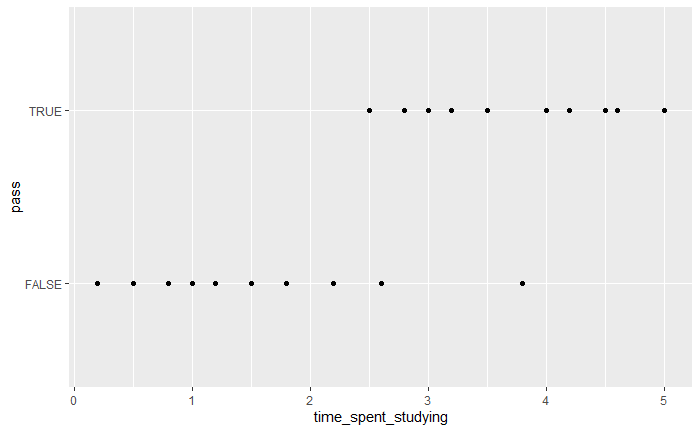

```r
student_results <- tibble(
  time_spent_studying = c(1.5, 1, 2.2, 1.2, 4.6, 5.0, 2.6, 2.5, 4, 3.2, 0.5, 0.8, 1.8, 4.5, 3.8, 2.8, 4.2, 3, 3.5, 0.2),
  pass = c(FALSE, FALSE, FALSE, FALSE, TRUE, TRUE, FALSE, TRUE, TRUE, TRUE, FALSE, FALSE, FALSE, TRUE, FALSE, TRUE, TRUE, TRUE, TRUE, FALSE)
)

logistic_model <- glm(pass ~ time_spent_studying, family = binomial(), student_results)


ggplot(student_results, aes(time_spent_studying, pass)) +
  geom_point()
```

Why doesn’t linear regression work for this data, exactly?

Can predict outside of the range High error

Instead a fit we might want would

predict a probability of pass / fail (always be between 0 and 1) would closely align with data points

- How on earth do we make a line do this?

We need to talk about Odds

Odds is a ratio of success : failure

odds of tossing a coin and getting a head

1 success (head)

1 failure (tail)

odds 1:1

Task - 2 mins If we roll a fair die, what are the odds of getting a 6?

1 : 5

```r
mortgage_data <- read_csv("data/mortgage_applications.csv") %>%
  janitor::clean_names()
mortgage_data
```

| tu_score | employed | age | accepted |
| --- | --- | --- | --- |
| 433 | TRUE | 28 | TRUE |
| 93 | TRUE | 52 | FALSE |
| 368 | FALSE | 63 | FALSE |
| 665 | TRUE | 42 | TRUE |
| 687 | TRUE | 38 | TRUE |
| 594 | TRUE | 27 | FALSE |
| 83 | FALSE | 24 | FALSE |
| 172 | TRUE | 19 | FALSE |
| 27 | FALSE | 45 | FALSE |
| 232 | FALSE | 34 | FALSE |

[output cut: 990 more lines]

```r
NA
```

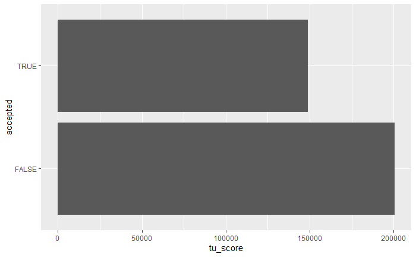

```r
mortgage_data %>%
  ggplot(aes(x = tu_score, y = accepted)) +
  geom_col()
```

```r
NA
```

logistic equation

```r
log_eq <- function(x, intercept, constant) {

  return(1 / (1 + exp(intercept + constant*x)))

}


x <- 1:10
log_eq(x, 0.1, 0.5)
```

```
 [1] 0.354343694 0.249739894 0.167981615 0.109096821 0.069138420 0.043107255
 [7] 0.026596994 0.016302499 0.009951802 0.006059801
```

```r
logit <- function (x) {

  return(log(x / (1 - x)))
}

logit_data <- tibble(p = seq(0.001, 0.999, 0.001)) %>%
  mutate(logit_p = logit(p))


head(logit_data)
```

| p | logit_p |
| --- | --- |
| 0.001 | -6.906755 |
| 0.002 | -6.212606 |
| 0.003 | -5.806138 |
| 0.004 | -5.517453 |
| 0.005 | -5.293305 |
| 0.006 | -5.109978 |

```r
NA
```

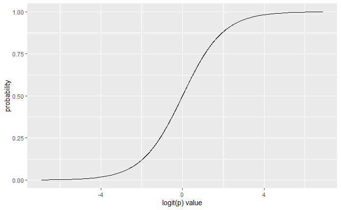

```r
logit_data %>%
  ggplot(aes(y = p, x = logit_p)) +
  geom_line() +
  labs(x = "logit(p) value",
       y = "probability")
```

```r
mortgage_data
```

| tu_score | employed | age | accepted |
| --- | --- | --- | --- |
| 433 | TRUE | 28 | TRUE |
| 93 | TRUE | 52 | FALSE |
| 368 | FALSE | 63 | FALSE |
| 665 | TRUE | 42 | TRUE |
| 687 | TRUE | 38 | TRUE |
| 594 | TRUE | 27 | FALSE |
| 83 | FALSE | 24 | FALSE |
| 172 | TRUE | 19 | FALSE |
| 27 | FALSE | 45 | FALSE |
| 232 | FALSE | 34 | FALSE |

[output cut: 990 more lines]

```r
NA
```

glm = generalised linear model, has exponent included somewhere in the model

```r
mortgage_data_logreg_model <- glm(accepted ~ tu_score,
                                  mortgage_data,
                                  family = binomial(link = "logit"))

summary(mortgage_data_logreg_model)
```

```
Call:
glm(formula = accepted ~ tu_score, family = binomial(link = "logit"),
    data = mortgage_data)

Deviance Residuals:
    Min       1Q   Median       3Q      Max
-1.8077  -0.6087  -0.2703   0.6851   3.0227

Coefficients:
             Estimate Std. Error z value Pr(>|z|)
(Intercept) -4.575035   0.285035  -16.05   <2e-16 ***
tu_score     0.008475   0.000566   14.97   <2e-16 ***
---
Signif. codes:  0 ‘***’ 0.001 ‘**’ 0.01 ‘*’ 0.05 ‘.’ 0.1 ‘ ’ 1

(Dispersion parameter for binomial family taken to be 1)

    Null deviance: 1170.48  on 999  degrees of freedom
Residual deviance:  792.14  on 998  degrees of freedom
AIC: 796.14

Number of Fisher Scoring iterations: 5
```

[output not shown]

[output cut: 990 more lines]

How do our odds of getting accepted for a mortgage change as we increase tu_score?

Odds at a baseline level (tu_score = 594) odds at a bit above the baseline level (tu_Score + 50)

how does increasing our tu_score (credit score) by 50 affect our odds?

```r
odds_change <- function(b1, change){

  exp(b1 * change)

}

odds_change(0.008475, 50)
```

```
[1] 1.52768
```

a 50 unit increase in tu_score increases our odds by a factor of 1.53

Next is categorical predictors

```r
mortgage_model_2_terms <- glm(
  accepted ~ tu_score + employed,
  mortgage_data,
  family = binomial(link = "logit")
)

summary(mortgage_model_2_terms)
```

```
Call:
glm(formula = accepted ~ tu_score + employed, family = binomial(link = "logit"),
    data = mortgage_data)

Deviance Residuals:
    Min       1Q   Median       3Q      Max
-1.8675  -0.5058  -0.2834   0.6397   2.9698

Coefficients:
               Estimate Std. Error z value Pr(>|z|)
(Intercept)  -4.6868275  0.2814919 -16.650  < 2e-16 ***
tu_score      0.0067239  0.0005679  11.840  < 2e-16 ***
employedTRUE  1.4845379  0.2102455   7.061 1.65e-12 ***
---
Signif. codes:  0 ‘***’ 0.001 ‘**’ 0.01 ‘*’ 0.05 ‘.’ 0.1 ‘ ’ 1

(Dispersion parameter for binomial family taken to be 1)

    Null deviance: 1170.48  on 999  degrees of freedom
Residual deviance:  739.99  on 997  degrees of freedom
AIC: 745.99

Number of Fisher Scoring iterations: 5
```

ln(Odds(Accepted)) = -4.6868275 + 0.0067239 * tu_score + 1.4845379 * employedTrue

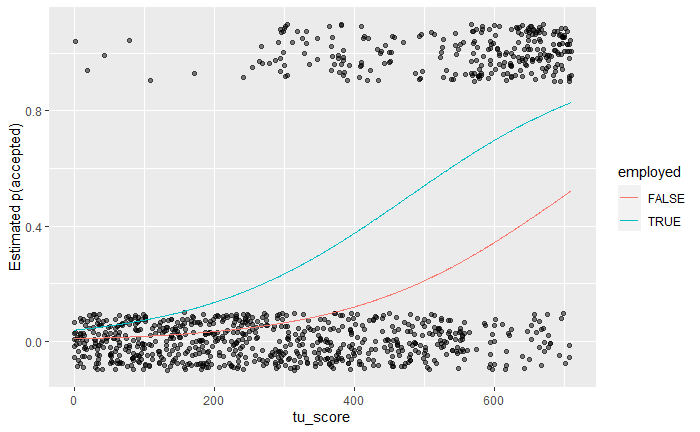

```r
log_predictions <- tibble(
  tu_score = rep(seq(0, 710, 1), 2),
  employed = c(rep(TRUE, 711), rep(FALSE, 711))
) %>%
  add_predictions(mortgage_model_2_terms,
                  type = "response")

ggplot(mortgage_data) +
  geom_jitter(aes(x = tu_score, y = as.numeric(accepted)), alpha = 0.5,
              height = 0.1, width = 0.1) +
  geom_line(data = log_predictions, aes(x = tu_score, y = pred,
                                        col = employed)) +
  labs(y = "Estimated p(accepted)")
```

```r
log_predictions %>%
  filter(tu_score == 600)
```

| tu_score | employed | pred |
| --- | --- | --- |
| 600 | TRUE | 0.6967935 |
| 600 | FALSE | 0.3424347 |

```r
NA
NA
```

Interpretation of categorical predictors:

Again we look at compared to our reference level

odds(employed = TRUE) / odds(employed = FALSE) = odds ratio

```r
odds_change(1.48, 1)
```

```
[1] 4.392946
```

On average, a customer’s odds of being accepted for a mortgage are 4.39 times higher if they are employed.

## Model Performance: Building a Binary Classifier

Rather than know the equation of a squiggle and how increasing / decreasing your credit score / employment status affected the probability you’d be accepted for a mortgage ….

A model that assigns a class based on this predicted probability

If applicant approaches our bank asking for a mortgage, if their credit score is X and their employment is Y, will we accept them for a loan or not.

The probability level at which we assign yes or no is called the threshold.

So for a 0.6 threshold, if the predicted probability of being accepted is greater than 0.6 –> accepted

```r
mortgage_pred_2_terms <- mortgage_data %>%
  # add predicted probabilities from the log model
  add_predictions(mortgage_model_2_terms,
                  type = "response") %>%
  # this is the binary classifier step
  mutate(predicted_accepted = pred >= 0.6)
```

Model Assessment - How often did we get it right?

1 Quick assessment tool: the Confusion Matrix The matrix outputs where the model is “confused”, i.e. not correctly classifying

```r
library(janitor)
mortgage_pred_2_terms %>%
  tabyl(accepted, predicted_accepted) %>%
  adorn_title()
```

```
          predicted_accepted
 accepted              FALSE TRUE
    FALSE                678   50
     TRUE                 93  179
```

Task - 5 mins - Preparation

Load and clean the names of mortgage_applications.csv. Re-run the logistic regression on the dataset, again treating the tu_score, age and employed variables as predictors and the accepted variable as the binary dependent. Keep the model object (call it mortgage_3pred_model) and use it to predict estimated probabilities for the sample data using add_predictions() (call this mortage_data_with_3pred) Look as the head() of the data with predicted probabilities.

```r
mortgage_3pred_model <- glm(
  accepted ~ tu_score + employed + age,
  mortgage_data,
  family = binomial(link = "logit")
)

summary(mortgage_3pred_model)
```

```
Call:
glm(formula = accepted ~ tu_score + employed + age, family = binomial(link = "logit"),
    data = mortgage_data)

Deviance Residuals:
    Min       1Q   Median       3Q      Max
-1.8827  -0.5069  -0.2852   0.6390   2.9650

Coefficients:
               Estimate Std. Error z value Pr(>|z|)
(Intercept)  -4.6285393  0.4303344 -10.756  < 2e-16 ***
tu_score      0.0067301  0.0005692  11.823  < 2e-16 ***
employedTRUE  1.4803410  0.2114794   7.000 2.56e-12 ***
age          -0.0012600  0.0070634  -0.178    0.858
---
Signif. codes:  0 ‘***’ 0.001 ‘**’ 0.01 ‘*’ 0.05 ‘.’ 0.1 ‘ ’ 1

(Dispersion parameter for binomial family taken to be 1)

    Null deviance: 1170.48  on 999  degrees of freedom
Residual deviance:  739.95  on 996  degrees of freedom
AIC: 747.95

Number of Fisher Scoring iterations: 5
```

```r
mortgage_data_with_3pred <- mortgage_data %>%
  # add predicted probabilities from the log model
  add_predictions(mortgage_3pred_model,
                  type = "response") %>%
  mutate(predicted_accepted = pred >= 0.6)

head(mortgage_data_with_3pred)
```

| tu_score | employed | age | accepted | pred | predicted_accepted |
| --- | --- | --- | --- | --- | --- |
| 433 | TRUE | 28 | TRUE | 0.43306982 | FALSE |
| 93 | TRUE | 52 | FALSE | 0.06992660 | FALSE |
| 368 | FALSE | 63 | FALSE | 0.09698035 | FALSE |
| 665 | TRUE | 42 | TRUE | 0.78149676 | TRUE |
| 687 | TRUE | 38 | TRUE | 0.80651348 | TRUE |
| 594 | TRUE | 27 | FALSE | 0.69327429 | TRUE |

```r
conf_mat <- mortgage_data_with_3pred %>%
  tabyl(accepted, predicted_accepted) %>%
  adorn_title()
```

De-mystify (hopefully) the confusion matrix output

You will always have: times your model was correct - FALSE/FALSE and TRUE/TRUE (679 + 179) and the times it was wrong at FALSE/TRUE and TRUE/FALSE (93 + 49)

What would the confusion matrix of a perfect classifier look like?

- 0s in the “incorrect” diagonal (T/F and F/T)

TN - True Negative - people didn’t get a mortgage, model predicts no mortgage TP - True Positive - people did get a mortgage, model predicts mortgage FN - False Negative - people did get a mortgage, model predicts no mortgage FP - False Positive - people didn’t get a mortgage, model predicts mortgage

Task - 5 mins Extract the rows in mortgage_data with tu_score = 594. Compare the sample data outcomes with the predicted outcomes of the threshold 0.6 classifier and say which of the following four groups each outcome belongs to: (i) true positive, (ii) true negative, (iii) false positive or (iv) false negative.

```r
mortgage_data_with_3pred %>%
  filter(tu_score == 594)
```

| tu_score | employed | age | accepted | pred | predicted_accepted |
| --- | --- | --- | --- | --- | --- |
| 594 | TRUE | 27 | FALSE | 0.6932743 | TRUE |
| 594 | TRUE | 47 | FALSE | 0.6878897 | TRUE |
| 594 | TRUE | 33 | TRUE | 0.6916643 | TRUE |
| 594 | TRUE | 36 | TRUE | 0.6908576 | TRUE |
| 594 | TRUE | 45 | TRUE | 0.6884305 | TRUE |

```r
# First two rows = FALSE POSITIVE
# Last 3 rows = TRUE POSITIVE
```

What measures of accuracy do we have? (How do we boil this down into a single value of accuracy?)

Accuracy = nTP + nTN / N

(times we were right) / (nrows)

```r
mortgage_data_with_3pred %>%
  summarise(accuracy = sum(accepted == predicted_accepted)/n())
```

| accuracy |
| --- |
| 0.858 |

```r
# 85.8% accuracy
```

We were correct in our predictions about 85% of the time.

The bad news is that accuracy has a subtle weakness.

Consider this case:

we run a test at the end of the school year for 1,000 students/ 900 students pass the test 100 students do not pass

What accuracy would my “always pass” model get?

900 100 0 0

The subtle weakness of accuracy then, is it’s reaction to unbalanced data.

This is why we’ve got other performance measures

- Accuracy
- Rates (True Positive Rate, Specificity, …)
- AUC } next lesson
- Gini }

- How to calculate? TNR = TN / N = TN / (TN + FP) = 1 - FPR
- Any other names for it? (Specificity, selectivity)

```r
# calculate true negative rate for mortgage data
mortgage_data_with_3pred %>%
  filter(!predicted_accepted) %>%
  summarise(TN = sum(accepted == predicted_accepted),
            N = n()) %>%
  summarise(TNR = TN / N)
```

[output not shown]

```r
NA
```

```r
conf_mat
```

```
          predicted_accepted
 accepted              FALSE TRUE
    FALSE                679   49
     TRUE                 93  179
```

```r
nTN = 679
nFP = 49
nFN = 93
nTP = 179

true_positive_rate = nTP / (nTP + nFN)
true_positive_rate
```

```
[1] 0.6580882
```

```r
true_negative_rate = nTN / (nTN + nFN)
true_negative_rate
```

[output not shown]

```r
false_positive_rate = nFP / (nFP + nTN)
false_positive_rate
```

```
[1] 0.06730769
```

```r
false_negative_rate = nFN / (nFN + nTP)
false_negative_rate
```

```
[1] 0.3419118
```

- the things / (the total number of items in that row)

Which should we prioritise?

no one answer to this, I’m afraid

A loan-giving based might not mind as many false positives (people being given loans that shouldn’t if it means they still give lots of loans to people they should)

But a disease-testing company might care a lot about false positives

we’re going to see

TPR and FPR again.